# Practical Machine Learning Course Project: Human Activity Recognition (HAR) data analysis and classification.

Michela Ieva

Friday, April 24, 2015

## Abstract

We propose an analysis of Human Activity Recognition (HAR) data about the “how well” an activity was performed. This kind of investigations potentially provides useful information for a large variety of applications, such as, sport training. We finally build a machine learning based classifier with an accurancy of 99.4%.

```r
library(knitr)
library(caret)
```

```r
library(ggplot2)

echo = TRUE  # Always make code visible
```

## Data taking and processing

In this research we use data[1] from accelerometers on the belt, forearm, arm, and dumbell of 6 participants into the study. They were asked to perform barbell lifts correctly and incorrectly in 5 different ways: exactly according to the specification (Class A), throwing the elbows to the front (Class B), lifting the dumbbell only halfway (Class C), lowering the dumbbell only halfway (Class D) and throwing the hips to the front (Class E).

Class A corresponds to the specified execution of the exercise, while the other 4 classes correspond to common mistakes.

First of all we download the data file and take a fast look to the data structure.

```r
datatraining <- read.csv("data/pml-training.csv")
str(datatraining)
```

```
## 'data.frame':    19622 obs. of  160 variables:
##  $ X                       : int  1 2 3 4 5 6 7 8 9 10 ...
##  $ user_name               : Factor w/ 6 levels "adelmo","carlitos",..: 2 2 2 2 2 2 2 2 2 2 ...
##  $ raw_timestamp_part_1    : int  1323084231 1323084231 1323084231 1323084232 1323084232 1323084232 1323084232 1323084232 1323084232 1323084232 ...
##  $ raw_timestamp_part_2    : int  788290 808298 820366 120339 196328 304277 368296 440390 484323 484434 ...
##  $ cvtd_timestamp          : Factor w/ 20 levels "02/12/2011 13:32",..: 9 9 9 9 9 9 9 9 9 9 ...
##  $ new_window              : Factor w/ 2 levels "no","yes": 1 1 1 1 1 1 1 1 1 1 ...
##  $ num_window              : int  11 11 11 12 12 12 12 12 12 12 ...
##  $ roll_belt               : num  1.41 1.41 1.42 1.48 1.48 1.45 1.42 1.42 1.43 1.45 ...
##  $ pitch_belt              : num  8.07 8.07 8.07 8.05 8.07 8.06 8.09 8.13 8.16 8.17 ...
##  $ yaw_belt                : num  -94.4 -94.4 -94.4 -94.4 -94.4 -94.4 -94.4 -94.4 -94.4 -94.4 ...
##  $ total_accel_belt        : int  3 3 3 3 3 3 3 3 3 3 ...
##  $ kurtosis_roll_belt      : Factor w/ 397 levels "","-0.016850",..: 1 1 1 1 1 1 1 1 1 1 ...
##  $ kurtosis_picth_belt     : Factor w/ 317 levels "","-0.021887",..: 1 1 1 1 1 1 1 1 1 1 ...
##  $ kurtosis_yaw_belt       : Factor w/ 2 levels "","#DIV/0!": 1 1 1 1 1 1 1 1 1 1 ...
```

[output cut: 86 more lines]

As you can see we have 19622 observables and 160 variables. The number of features is to high, we need to clean and pre-process the data to create a good classifier.

### Data partitioning for training and testing samples creation

In order to build the classifier we need to divide the data in two samples: training (70%) and testing (30%) to perform cross validation after fitting model.

```r
set.seed(23274) # For reproducibile purpose
intrain <- createDataPartition(y=datatraining$classe, p=0.7, list=FALSE)
training <- datatraining[intrain,]
testing <- datatraining[-intrain,]
dim(training)
```

```
## [1] 13737   160
```

```r
dim(testing)
```

```
## [1] 5885  160
```

With a fast look at the variables types and values, we see that the first 7 columns are Factors/strings not important for classification. Furthermore, there are a lot of variables not directly measured, but derived from measurements so higly correlated. Considering that correlated variables could strongly affect the accurancy of classification, we decide to remove them.

```r
subdatatraining <-training[, 8:159]
subdatatraining <- subdatatraining[,-grep("^var|^avg|^stddev|^min|^max|^ampl|^skew|^kurt", colnames(subdatatraining))]
```

Finally we need to reshape a little bit the data sample to include the outcome variable *classe* as first column.

```r
classe <- training[, 160]
finaltrainingdata <- cbind(classe, subdatatraining)
str(finaltrainingdata)
```

```
## 'data.frame':    13737 obs. of  53 variables:
##  $ classe              : Factor w/ 5 levels "A","B","C","D",..: 1 1 1 1 1 1 1 1 1 1 ...
##  $ roll_belt           : num  1.41 1.41 1.42 1.45 1.42 1.42 1.43 1.45 1.45 1.42 ...
##  $ pitch_belt          : num  8.07 8.07 8.07 8.06 8.09 8.13 8.16 8.17 8.18 8.2 ...
##  $ yaw_belt            : num  -94.4 -94.4 -94.4 -94.4 -94.4 -94.4 -94.4 -94.4 -94.4 -94.4 ...
##  $ total_accel_belt    : int  3 3 3 3 3 3 3 3 3 3 ...
##  $ gyros_belt_x        : num  0 0.02 0 0.02 0.02 0.02 0.02 0.03 0.03 0.02 ...
##  $ gyros_belt_y        : num  0 0 0 0 0 0 0 0 0 0 ...
##  $ gyros_belt_z        : num  -0.02 -0.02 -0.02 -0.02 -0.02 -0.02 -0.02 0 -0.02 0 ...
##  $ accel_belt_x        : int  -21 -22 -20 -21 -22 -22 -20 -21 -21 -22 ...
##  $ accel_belt_y        : int  4 4 5 4 3 4 2 4 2 4 ...
##  $ accel_belt_z        : int  22 22 23 21 21 21 24 22 23 21 ...
##  $ magnet_belt_x       : int  -3 -7 -2 0 -4 -2 1 -3 -5 -3 ...
##  $ magnet_belt_y       : int  599 608 600 603 599 603 602 609 596 606 ...
##  $ magnet_belt_z       : int  -313 -311 -305 -312 -311 -313 -312 -308 -317 -309 ...
```

[output cut: 39 more lines]

We have to do excactly the same cleaning steps on the testing sample.

```r
subdatatesting <-testing[, 8:159]
subdatatesting <- subdatatesting[,-grep("^var|^avg|^stddev|^min|^max|^ampl|^skew|^kurt", colnames(subdatatesting))]
classe <- testing[, 160]
finaldatatesting <- cbind(classe, subdatatesting)
str(finaldatatesting)
```

```
## 'data.frame':    5885 obs. of  53 variables:
##  $ classe              : Factor w/ 5 levels "A","B","C","D",..: 1 1 1 1 1 1 1 1 1 1 ...
##  $ roll_belt           : num  1.48 1.48 1.43 1.55 1.44 1.41 1.41 1.39 1.34 1.3 ...
##  $ pitch_belt          : num  8.05 8.07 8.18 8.08 8.19 8.18 8.11 8.05 8.05 8 ...
##  $ yaw_belt            : num  -94.4 -94.4 -94.4 -94.4 -94.4 -94.4 -94.3 -94.3 -94.3 -94.2 ...
##  $ total_accel_belt    : int  3 3 3 3 3 3 3 3 3 3 ...
##  $ gyros_belt_x        : num  0.02 0.02 0.02 0 0.02 0 0 0 0 -0.02 ...
##  $ gyros_belt_y        : num  0 0.02 0 0.02 0 0 0.02 0 0.02 0.02 ...
##  $ gyros_belt_z        : num  -0.03 -0.02 -0.02 0 -0.03 -0.03 -0.02 -0.03 -0.03 -0.03 ...
##  $ accel_belt_x        : int  -22 -21 -22 -21 -21 -22 -20 -22 -22 -21 ...
##  $ accel_belt_y        : int  3 2 2 5 5 4 3 1 3 3 ...
##  $ accel_belt_z        : int  21 24 23 21 21 22 22 21 20 22 ...
##  $ magnet_belt_x       : int  -6 -6 -2 1 -4 1 0 1 2 -4 ...
##  $ magnet_belt_y       : int  604 600 602 600 603 600 606 606 602 599 ...
##  $ magnet_belt_z       : int  -310 -302 -319 -316 -315 -301 -317 -310 -317 -316 ...
```

[output cut: 39 more lines]

## Fitting the Model

For this kind of problems, non linear multi-class supervised learning, one of the most effective and powerfull method, among the most commonly used, is Random Forest. Let build it.

```r
modelfitRFnopca <-train(finaltrainingdata$classe ~ ., method="rf", data=finaltrainingdata)
modelfitRFnopca
```

```
## Random Forest
##
## 13737 samples
##    52 predictor
##     5 classes: 'A', 'B', 'C', 'D', 'E'
##
## No pre-processing
## Resampling: Bootstrapped (25 reps)
##
## Summary of sample sizes: 13737, 13737, 13737, 13737, 13737, 13737, ...
##
## Resampling results across tuning parameters:
##
##   mtry  Accuracy   Kappa      Accuracy SD  Kappa SD
##    2    0.9893332  0.9865013  0.001582804  0.001999560
##   27    0.9887888  0.9858135  0.002145570  0.002708017
##   52    0.9775766  0.9716235  0.004426458  0.005597602
##
## Accuracy was used to select the optimal model using  the largest value.
## The final value used for the model was mtry = 2.
```

As you can see the model uses all the 52 observables for predictions and the default choice for intrinsic resampling and validation is bootstrapping with 25 samples.

### Model Testing

Now we have to test this model over the cross validation data sample to evaluate the accurancy.

```r
modelpredictionTeS <- predict(modelfitRFnopca, newdata = finaldatatesting)
accuracy <- confusionMatrix(modelpredictionTeS, finaldatatesting$classe)
print(accuracy)
```

```
## Confusion Matrix and Statistics
##
##           Reference
## Prediction    A    B    C    D    E
##          A 1674    5    0    0    0
##          B    0 1130   13    0    0
##          C    0    4 1012   11    0
##          D    0    0    1  951    0
##          E    0    0    0    2 1082
##
## Overall Statistics
##
##                Accuracy : 0.9939
##                  95% CI : (0.9915, 0.9957)
##     No Information Rate : 0.2845
##     P-Value [Acc > NIR] : < 2.2e-16
##
##                   Kappa : 0.9923
##  Mcnemar's Test P-Value : NA
##
## Statistics by Class:
##
##                      Class: A Class: B Class: C Class: D Class: E
## Sensitivity            1.0000   0.9921   0.9864   0.9865   1.0000
## Specificity            0.9988   0.9973   0.9969   0.9998   0.9996
## Pos Pred Value         0.9970   0.9886   0.9854   0.9989   0.9982
## Neg Pred Value         1.0000   0.9981   0.9971   0.9974   1.0000
## Prevalence             0.2845   0.1935   0.1743   0.1638   0.1839
## Detection Rate         0.2845   0.1920   0.1720   0.1616   0.1839
## Detection Prevalence   0.2853   0.1942   0.1745   0.1618   0.1842
## Balanced Accuracy      0.9994   0.9947   0.9916   0.9932   0.9998
```

So, the model is quite accurate: 99.4% and the the out-of-sample error could be estimated by

```r
table(finaldatatesting$classe, modelpredictionTeS)
```

```
##    modelpredictionTeS
##        A    B    C    D    E
##   A 1674    0    0    0    0
##   B    5 1130    4    0    0
##   C    0   13 1012    1    0
##   D    0    0   11  951    2
##   E    0    0    0    0 1082
```

```r
nright = table(modelpredictionTeS == finaldatatesting$classe)
oose = as.vector(100 * (1-nright["TRUE"] / sum(nright)))
oose
```

```
## [1] 0.6117247
```

We can visualize the classifier results on the cross-validation sample plotting a normalized confusion matrix.

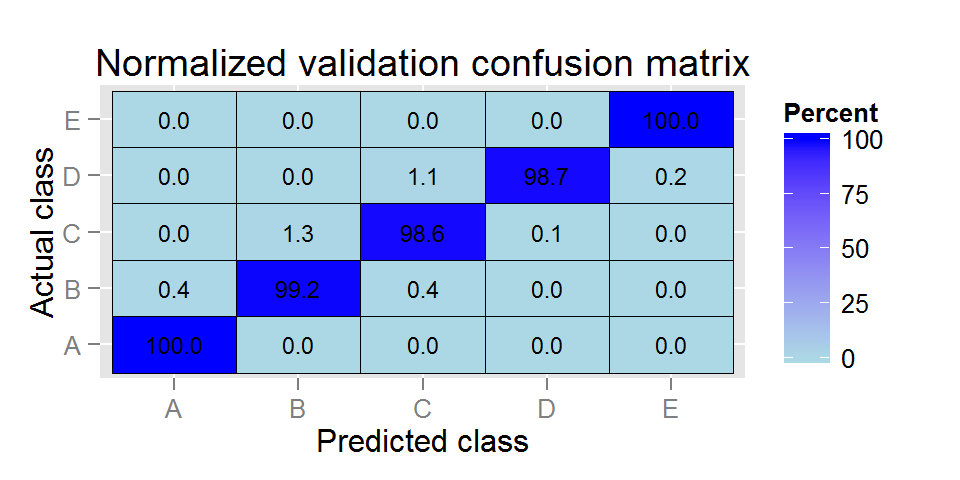

```r
accuracy <- confusionMatrix(modelpredictionTeS, finaldatatesting$classe)
confusion = as.data.frame(table(finaldatatesting$classe, modelpredictionTeS))
names(confusion) = c("Actual","Predicted","Freq")

actual = as.data.frame(table(finaldatatesting$classe))
names(actual) = c("Actual","ActualFreq")

confusion = merge(confusion, actual, by=c("Actual"))
confusion$Percent = confusion$Freq/confusion$ActualFreq*100

tile <- ggplot() +
        geom_tile(aes(x=Predicted, y=Actual,fill=Percent),data=confusion, color="black",size=0.1) +
        labs(x="Predicted class",y="Actual class") + ggtitle("Normalized validation confusion matrix")
tile = tile +
        geom_text(aes(x=Predicted,y=Actual, label=sprintf("%.1f", Percent)),data=confusion, size=3, colour="black") +
        scale_fill_gradient(low="light blue",high="blue")

tile = tile +
        geom_tile(aes(x=Predicted,y=Actual),data=subset(confusion, as.character(Actual)==as.character(Predicted)), color="black",size=0.3, fill="black", alpha=0)

tile
```

### Model Reviewing

In order to speed up the fitting procedure we try to reduce the numbers of variables used for prediction with tha PCA techinique of dimensionality reduction. So, before fitting we pre-process the data to reduce the number of features.

```r
pca <- preProcess(finaltrainingdata[, -1], method = "pca",thresh = 0.80, pcaComp = NULL,na.remove = TRUE)
pca
```

```
##
## Call:
## preProcess.default(x = finaltrainingdata[, -1], method = "pca", thresh
##  = 0.8, pcaComp = NULL, na.remove = TRUE)
##
## Created from 13737 samples and 52 variables
## Pre-processing: principal component signal extraction, scaled, centered
##
## PCA needed 13 components to capture 80 percent of the variance
```

```r
traineddata <- predict(pca, finaltrainingdata[, -1])
```

Now we apply the fitting procedure

```r
modelfitRFwithpca <-train(finaltrainingdata$classe ~ ., method="rf", data=traineddata)
modelfitRFwithpca
```

[output not shown]

and check the accurancy on the testing data

```r
testeddata <- predict(pca, finaldatatesting[, -1])
confusionMatrix(finaldatatesting$classe, predict(modelfitRFwithpca, testeddata))
```

```
## Confusion Matrix and Statistics
##
##           Reference
## Prediction    A    B    C    D    E
##          A 1637   12   20    3    2
##          B   18 1093   25    0    3
##          C   15   16  977   14    4
##          D    7    0   25  929    3
##          E    2   18   11    5 1046
##
## Overall Statistics
##
##                Accuracy : 0.9655
##                  95% CI : (0.9605, 0.97)
##     No Information Rate : 0.2853
##     P-Value [Acc > NIR] : < 2.2e-16
##
##                   Kappa : 0.9564
##  Mcnemar's Test P-Value : NA
##
## Statistics by Class:
##
##                      Class: A Class: B Class: C Class: D Class: E
## Sensitivity            0.9750   0.9596   0.9234   0.9769   0.9887
## Specificity            0.9912   0.9903   0.9898   0.9929   0.9925
## Pos Pred Value         0.9779   0.9596   0.9522   0.9637   0.9667
## Neg Pred Value         0.9900   0.9903   0.9833   0.9955   0.9975
## Prevalence             0.2853   0.1935   0.1798   0.1616   0.1798
## Detection Rate         0.2782   0.1857   0.1660   0.1579   0.1777
## Detection Prevalence   0.2845   0.1935   0.1743   0.1638   0.1839
## Balanced Accuracy      0.9831   0.9750   0.9566   0.9849   0.9906
```

As you can see from the above statistic the application of PCA decreases a little bit the accurancy, even if the now the model fitting time is considerably reduced.

## Results

The Random Forest clearly performs better without PCA, approaching 99.4% accuracy so we select this model and apply it to the original test data set preprocessed exactly as the training data sample.

```r
datatobepredicted <- read.csv("data/pml-testing.csv")
subdatatobepredicted <-datatobepredicted[, 8:159]
subdatatobepredicted <- subdatatobepredicted[,-grep("^var|^avg|^stddev|^min|^max|^ampl|^skew|^kurt", colnames(subdatatobepredicted))]

results <- predict(modelfitRFnopca, newdata=subdatatobepredicted)
results <- as.character(results)
results
```

```
##  [1] "B" "A" "B" "A" "A" "E" "D" "B" "A" "A" "B" "C" "B" "A" "E" "E" "A"
## [18] "B" "B" "B"
```

## Conclusion

In this analysis we build a classification model for HAR data analysis using the Random Forest algorithm. We found this model reachs an accuracy of 99.4% for the out-of-sample data set. Using this model, we were able to correctly classify all twenty values from the test data set.

## References

[1] Velloso, E.; Bulling, A.; Gellersen, H.; Ugulino, W.; Fuks, H. Qualitative Activity Recognition of Weight Lifting Exercises. Proceedings of 4th International Conference in Cooperation with SIGCHI (Augmented Human ’13) . Stuttgart, Germany: ACM SIGCHI, 2013.